# Getting Started with R Markdown

Jessi Cisewski Kehe

Fall 2020

This R Markdown document was adapted from a document created by Professor Bret Lager.

## R Markdown

We are in an R Markdown document

R Markdown is useful for organizing, explaining, and sharing your analyses

You can include code and code output along with any commentary

We will use it for lectures, homework assignments, discussion session assignments, and your final project

- R Markdown website: http://rmarkdown.rstudio.com
- See Chapter 27 of R4DS for a thorough introduction
- R Markdown files are created and edited in RStudio
  - Open a new R Markdown file from RStudio menu bar: File > New File > R Markdown
  - Type of file: plain text
  - Extension: .Rmd
  - Can be used for creating different file types, but we will primarily create .html files
- An R Markdown file typically begins with a YAML header
  - This header is not in a markdown language
  - YAML = “YAML Ain’t Markup Language”
- R Markdown cheatsheets are available through RStudio
  - R Markdown Cheat Sheet: Help > Cheatsheets > R Markdown Cheat Sheet
  - R Markdown Reference Guide: Help > Cheatsheets > R Markdown Reference Guide

## Markdown

Markdown is the syntax used in R Markdown documents for formatting the text and layout.

Below are examples of the syntax for headers, lists, font types, and adding a hyperlink.

```
# A big header
## A smaller header
### H3
#### H4
##### H5
###### The smallest header size

1. A numbered list
2. Next item
    - sub item 1
    - sub item 2
4. The number 4 will be changed to a 3! Haha :-)
    * can use an asterisk
    + or a plus

**Bold text** and *italic text*.
Can also do __bold__ and _italic_.

Here is a link to the cheatsheet [R Markdown Cheatsheet](https://raw.githubusercontent.com/rstudio/cheatsheets/master/rmarkdown-2.0.pdf)
```

# A big header

## A smaller header

### H3

#### H4

##### H5

###### The smallest header size

1. A numbered list
2. Next item
   - sub item 1
   - sub item 2
3. The number 4 will be changed to a 3! Haha :-)
   - can use an asterisk
   - or a plus

**Bold text** and *italic text*.  
Can also do **bold** and *italic*.

Here is a link to the cheatsheet [R Markdown Cheatsheet](https://raw.githubusercontent.com/rstudio/cheatsheets/master/rmarkdown-2.0.pdf)

### Chunks

Code chunks are between triple back quotes. An R code chunk is best written like this example.

````
```{r chunk-label, chunk-option-name=value}
Some R code here
```
````

The `chunk-label` is not required, but if included should be the first option in the header (after the `r`). If you don’t specify the label, one will be automatically assigned (like `unnamed-chunk-i` for some number `i`). These labels are used for things like finding errors or as file names of plots generated by the chunk.

For example, here is a chunk with the label `setup` that loads the *tidyverse* package and assigns a value to the variable `x` and prints it. The other options in the header suppress warnings (`warning=FALSE`) and messages (`message=FALSE`) created in the chunk, and executes the chunk without being included in the final document. If you want any output included in the final document but not the code, you can use `echo=FALSE` in the chunk header.

````
```{r setup, include=FALSE, warning=FALSE, message=FALSE}
library(tidyverse)
x <- 2+2
x
```
````

```r
library(tidyverse)
x <- 2+7
x
```

```
## [1] 9
```

There are various options that can be included in the chunk header (between the `` ```{r `` and the `}`).

You can reference variable within the text as well. For example, the value of `x` can be displayed using 9 (see the .Rmd)

Plots can also be embedded in the final document. Using the following chunk, the code and plot will display in our final document.

````
```{r simple, echo=TRUE}
x <- 1:10
y <- x + rnorm(10)
plot(x,y)
```
````

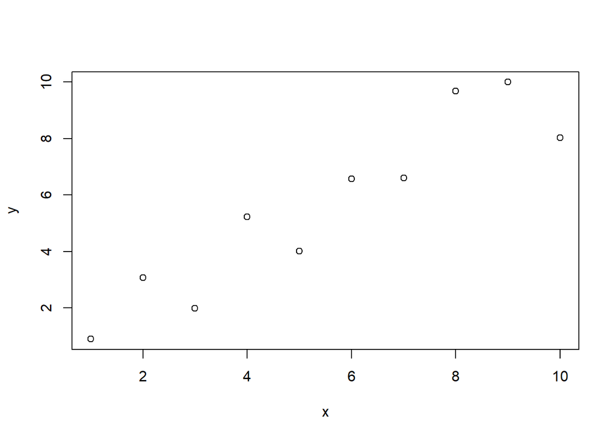

You will pickup more tips and tricks on the chunks as the semester progresses.  
Copying examples and experimenting will be a great way to learn!

### Knitting

Click on the **knit** button to render the document into HTML or PDF. If you click on the little down arrow, you can choose. By default, it picks what is in the YAML section (or HTML if nothing is specified in YAML).

When the document is knit, all code chunks are run with a fresh R environment and the output is included in the final document as specified.